# Motivation

The objective of this project is to investigate the relationships between various attributes of songs and identify the key features that effectively differentiate between genres. Given that the dataset lacks explicit genre labels, we will employ unsupervised learning methods, specifically clustering algorithms, to organize the songs into distinct groups. These groups, formed based on similarities in their musical attributes, will serve as proxies for genres. Through this approach, we aim to uncover the underlying patterns in the data that signal genre distinctions, despite the absence of pre-defined genre classifications.

# Import Libraries

```python
import pandas as pd
import seaborn as sns
import matplotlib.pyplot as plt
from sklearn.preprocessing import StandardScaler
from sklearn.cluster import KMeans
from sklearn.metrics import silhouette_score
from sklearn.decomposition import PCA
```

# Data Cleaning and Manipulation

```python
df = pd.read_csv("Desktop/Data/spotify_data.csv")

# Drop unncessary column
df.drop('Unnamed: 0', axis = 1, inplace = True)
df.head()
```

|  | acousticness | danceability | duration_ms | energy | instrumentalness | key | liveness | loudness | mode | speechiness | tempo | time_signature | valence | target | song_title | artist |
| --- | --- | --- | --- | --- | --- | --- | --- | --- | --- | --- | --- | --- | --- | --- | --- | --- |
| 0 | 0.0102 | 0.833 | 204600 | 0.434 | 0.021900 | 2 | 0.1650 | -8.795 | 1 | 0.4310 | 150.062 | 4.0 | 0.286 | 1 | Mask Off | Future |
| 1 | 0.1990 | 0.743 | 326933 | 0.359 | 0.006110 | 1 | 0.1370 | -10.401 | 1 | 0.0794 | 160.083 | 4.0 | 0.588 | 1 | Redbone | Childish Gambino |
| 2 | 0.0344 | 0.838 | 185707 | 0.412 | 0.000234 | 2 | 0.1590 | -7.148 | 1 | 0.2890 | 75.044 | 4.0 | 0.173 | 1 | Xanny Family | Future |
| 3 | 0.6040 | 0.494 | 199413 | 0.338 | 0.510000 | 5 | 0.0922 | -15.236 | 1 | 0.0261 | 86.468 | 4.0 | 0.230 | 1 | Master Of None | Beach House |
| 4 | 0.1800 | 0.678 | 392893 | 0.561 | 0.512000 | 5 | 0.4390 | -11.648 | 0 | 0.0694 | 174.004 | 4.0 | 0.904 | 1 | Parallel Lines | Junior Boys |

```python
# Check for missing values
df.isnull().sum()
```

```
acousticness        0
danceability        0
duration_ms         0
energy              0
instrumentalness    0
key                 0
liveness            0
loudness            0
mode                0
speechiness         0
tempo               0
time_signature      0
valence             0
target              0
song_title          0
artist              0
dtype: int64
```

```python
# Remove duplicated rows that have the same 'song_title' and 'artist'
df_unique = df.drop_duplicates(subset=['song_title', 'artist'])

# Check how many rows were removed
rows_removed = len(df) - len(df_unique)
rows_removed, len(df_unique)
```

```
(35, 1982)
```

```python
df.head()
```

|  | acousticness | danceability | duration_ms | energy | instrumentalness | key | liveness | loudness | mode | speechiness | tempo | time_signature | valence | target | song_title | artist |
| --- | --- | --- | --- | --- | --- | --- | --- | --- | --- | --- | --- | --- | --- | --- | --- | --- |
| 0 | 0.0102 | 0.833 | 204600 | 0.434 | 0.021900 | 2 | 0.1650 | -8.795 | 1 | 0.4310 | 150.062 | 4.0 | 0.286 | 1 | Mask Off | Future |
| 1 | 0.1990 | 0.743 | 326933 | 0.359 | 0.006110 | 1 | 0.1370 | -10.401 | 1 | 0.0794 | 160.083 | 4.0 | 0.588 | 1 | Redbone | Childish Gambino |
| 2 | 0.0344 | 0.838 | 185707 | 0.412 | 0.000234 | 2 | 0.1590 | -7.148 | 1 | 0.2890 | 75.044 | 4.0 | 0.173 | 1 | Xanny Family | Future |
| 3 | 0.6040 | 0.494 | 199413 | 0.338 | 0.510000 | 5 | 0.0922 | -15.236 | 1 | 0.0261 | 86.468 | 4.0 | 0.230 | 1 | Master Of None | Beach House |
| 4 | 0.1800 | 0.678 | 392893 | 0.561 | 0.512000 | 5 | 0.4390 | -11.648 | 0 | 0.0694 | 174.004 | 4.0 | 0.904 | 1 | Parallel Lines | Junior Boys |

# Correlation Matrix

```python
#Correlation Matrix
excluded_columns = ['song_title', 'artist', 'target']
correlation_matrix = df_unique.drop(columns=excluded_columns).corr()

correlation_matrix
```

|  | acousticness | danceability | duration_ms | energy | instrumentalness | key | liveness | loudness | mode | speechiness | tempo | time_signature | valence |
| --- | --- | --- | --- | --- | --- | --- | --- | --- | --- | --- | --- | --- | --- |
| acousticness | 1.000000 | -0.175379 | 0.063862 | -0.648646 | 0.136591 | -0.080752 | -0.119286 | -0.562271 | 0.072025 | -0.097193 | -0.125871 | -0.191163 | -0.151916 |
| danceability | -0.175379 | 1.000000 | 0.010250 | 0.032996 | -0.132124 | 0.021146 | -0.131976 | 0.101381 | -0.046977 | 0.139530 | -0.147880 | 0.128301 | 0.442779 |
| duration_ms | 0.063862 | 0.010250 | 1.000000 | -0.139489 | 0.302758 | 0.025022 | 0.014843 | -0.269638 | -0.073776 | -0.079191 | -0.074597 | -0.042966 | -0.115000 |
| energy | -0.648646 | 0.032996 | -0.139489 | 1.000000 | -0.119672 | 0.073421 | 0.221449 | 0.763140 | -0.073737 | 0.100331 | 0.166507 | 0.184091 | 0.272631 |
| instrumentalness | 0.136591 | -0.132124 | 0.302758 | -0.119672 | 1.000000 | -0.008979 | 0.003487 | -0.351664 | -0.026781 | -0.154941 | 0.002322 | -0.072794 | -0.194599 |
| key | -0.080752 | 0.021146 | 0.025022 | 0.073421 | -0.008979 | 1.000000 | 0.048346 | 0.049506 | -0.190984 | 0.020509 | 0.042166 | 0.025420 | 0.031310 |
| liveness | -0.119286 | -0.131976 | 0.014843 | 0.221449 | 0.003487 | 0.048346 | 1.000000 | 0.159837 | -0.013732 | 0.090804 | 0.014586 | 0.017506 | -0.048852 |
| loudness | -0.562271 | 0.101381 | -0.269638 | 0.763140 | -0.351664 | 0.049506 | 0.159837 | 1.000000 | -0.047926 | 0.092406 | 0.154550 | 0.145692 | 0.201740 |
| mode | 0.072025 | -0.046977 | -0.073776 | -0.073737 | -0.026781 | -0.190984 | -0.013732 | -0.047926 | 1.000000 | -0.053552 | -0.065041 | -0.037676 | -0.034710 |
| speechiness | -0.097193 | 0.139530 | -0.079191 | 0.100331 | -0.154941 | 0.020509 | 0.090804 | 0.092406 | -0.053552 | 1.000000 | 0.111402 | 0.114025 | 0.060162 |
| tempo | -0.125871 | -0.147880 | -0.074597 | 0.166507 | 0.002322 | 0.042166 | 0.014586 | 0.154550 | -0.065041 | 0.111402 | 1.000000 | -0.056800 | -0.013792 |
| time_signature | -0.191163 | 0.128301 | -0.042966 | 0.184091 | -0.072794 | 0.025420 | 0.017506 | 0.145692 | -0.037676 | 0.114025 | -0.056800 | 1.000000 | 0.137170 |
| valence | -0.151916 | 0.442779 | -0.115000 | 0.272631 | -0.194599 | 0.031310 | -0.048852 | 0.201740 | -0.034710 | 0.060162 | -0.013792 | 0.137170 | 1.000000 |

```python
correlation_pairs_excluded_filtered_copy = correlation_pairs_excluded_filtered.copy()
correlation_pairs_excluded_filtered_copy['AbsoluteCorrelation'] = correlation_pairs_excluded_filtered_copy['Correlation'].abs()

correlation_pairs_excluded_sorted_copy = correlation_pairs_excluded_filtered_copy.sort_values(by='AbsoluteCorrelation', ascending=False)
correlation_pairs_excluded_sorted_unique_copy = correlation_pairs_excluded_sorted_copy.drop_duplicates(subset=['AbsoluteCorrelation'], keep='first')

# Display the top correlated pairs in descending order
correlation_pairs_excluded_sorted_unique_copy.head()
```

[output not shown]

|  | Feature1 | Feature2 | Correlation | AbsoluteCorrelation |
| --- | --- | --- | --- | --- |
| 46 | energy | loudness | 0.762177 | 0.762177 |
| 39 | energy | acousticness | -0.646319 | 0.646319 |
| 91 | loudness | acousticness | -0.562021 | 0.562021 |
| 25 | danceability | valence | 0.442061 | 0.442061 |
| 59 | instrumentalness | loudness | -0.354625 | 0.354625 |

# Heatmap

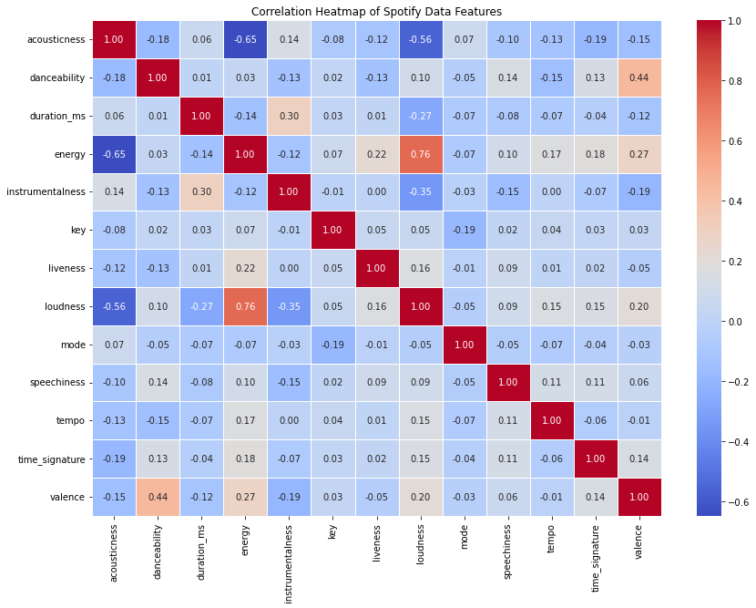

```python
# Set the size of the heatmap
plt.figure(figsize=(14, 10))

# Create the heatmap using seaborn
sns.heatmap(correlation_matrix, annot=True, fmt=".2f", cmap='coolwarm', linewidths=.5)

# Show the heatmap
plt.title('Correlation Heatmap of Spotify Data Features')
plt.show()
```

##### Energy and Loudness:

There's a strong positive correlation (0.762), suggesting that tracks with higher energy levels tend to be louder.

##### Acousticness and Energy:

These two features have a strong negative correlation (-0.646), indicating that more acoustic tracks tend to have lower energy levels.

##### Danceability and Valence:

There's a moderate positive correlation (0.442), suggesting that tracks that are more danceable tend to have a happier or more positive mood.

##### Duration and Instrumentalness:

A moderate positive correlation (0.305) suggests that longer tracks are more likely to be instrumental.

# SPLOM

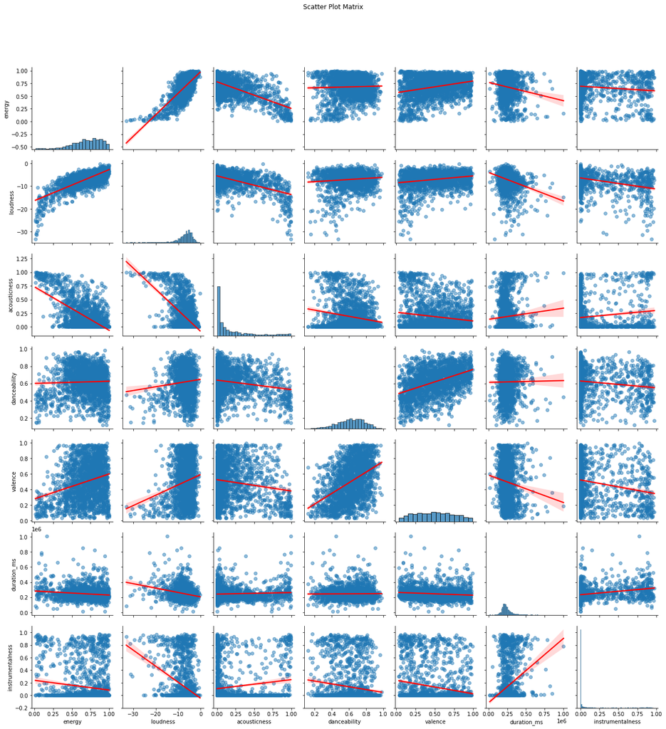

```python
# Selecting the specified variables for the scatter plot matrix
columns_of_interest = ['energy', 'loudness', 'acousticness', 'danceability', 'valence', 'duration_ms', 'instrumentalness']
subset_df = df_unique[columns_of_interest]

# Creating scatter plot matrix
g = sns.pairplot(subset_df, kind="reg", plot_kws={'line_kws':{'color':'red'}, 'scatter_kws': {'alpha': 0.5}})
g.fig.suptitle("Scatter Plot Matrix", y=1.08)

plt.show()
```

# K-Means Clustering

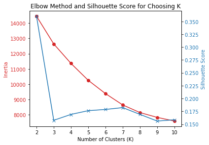

```python
# 1. Feature Selection: Selecting features that could be relevant for genre classification
features_for_clustering = ['acousticness', 'danceability', 'energy', 'instrumentalness', 'liveness', 'loudness', 'speechiness', 'tempo', 'valence']
X = df_unique[features_for_clustering]

# 2. Preprocessing: Normalizing the data
scaler = StandardScaler()
X_scaled = scaler.fit_transform(X)

# 3. Choosing K: Using the Elbow Method and Silhouette Score to determine an appropriate number of clusters
inertia = []
silhouette_scores = []
K_range = range(2, 11)  # Testing a range from 2 to 10 clusters

for k in K_range:
    kmeans = KMeans(n_clusters=k, random_state=42)
    kmeans.fit(X_scaled)
    inertia.append(kmeans.inertia_)
    silhouette_scores.append(silhouette_score(X_scaled, kmeans.labels_))

# Plotting the results to help choose K
fig, ax1 = plt.subplots()

color = 'tab:red'
ax1.set_xlabel('Number of Clusters (K)')
ax1.set_ylabel('Inertia', color=color)
ax1.plot(K_range, inertia, marker='o', color=color)
ax1.tick_params(axis='y', labelcolor=color)

ax2 = ax1.twinx()
color = 'tab:blue'
ax2.set_ylabel('Silhouette Score', color=color)
ax2.plot(K_range, silhouette_scores, marker='x', color=color)
ax2.tick_params(axis='y', labelcolor=color)

fig.tight_layout()
plt.title('Elbow Method and Silhouette Score for Choosing K')
plt.show()
```

The plot shows both the inertia (sum of squared distances to the nearest cluster center) and the silhouette score (measure of how similar an object is to its own cluster compared to other clusters) for different numbers of clusters (K) ranging from 2 to 10.

```python
# Ensure df_unique is a standalone DataFrame to avoid SettingWithCopyWarning
df_unique = df_unique.copy()

# Apply K-Means Clustering with the chosen K
optimal_k = 5  # This value is chosen based on observed trends in elbow and silhouette scores
kmeans = KMeans(n_clusters=optimal_k, random_state=42)

# Assign cluster labels using .loc to ensure direct modification
df_unique.loc[:, 'cluster'] = kmeans.fit_predict(X_scaled)

# Count the number of tracks in each cluster
cluster_counts = df_unique['cluster'].value_counts()

print(cluster_counts)
```

```
0    760
3    621
4    219
2    211
1    171
Name: cluster, dtype: int64
```

# PCA and Cluster Visualization

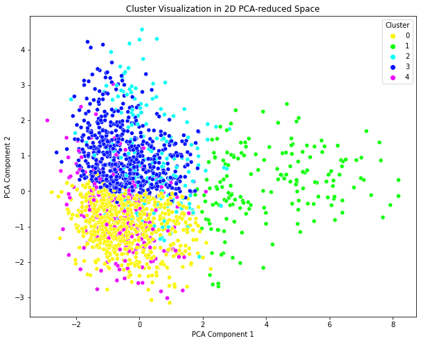

```python
# Since we have multiple dimensions, we'll use PCA to reduce the data to 2D for visualization purposes

# Reduce data to two dimensions
pca = PCA(n_components=2)
X_pca = pca.fit_transform(X_scaled)

# Scatter plot of the two PCA components colored by cluster
plt.figure(figsize=(10, 8))
sns.scatterplot(x=X_pca[:, 0], y=X_pca[:, 1], hue=df_unique['cluster'], palette=sns.color_palette("hsv", optimal_k), legend="full")
plt.title('Cluster Visualization in 2D PCA-reduced Space')
plt.xlabel('PCA Component 1')
plt.ylabel('PCA Component 2')
plt.legend(title='Cluster')
plt.show()
```

These clusters represent groupings of tracks based on their features, such as acousticness, danceability, energy, etc. Each cluster could potentially correspond to different musical styles or genres, based on the similarity of their audio features.

# PC Loadings

```python
# Compute the PCA loadings (components) to understand the contribution of each original feature to the PCA components
pca_loadings = pca.components_

# Create a DataFrame for better readability of the PCA loadings
pca_loadings_df = pd.DataFrame(pca_loadings, columns=features_for_clustering, index=['PCA Component 1', 'PCA Component 2'])

pca_loadings_df
```

|  | acousticness | danceability | energy | instrumentalness | liveness | loudness | speechiness | tempo | valence |
| --- | --- | --- | --- | --- | --- | --- | --- | --- | --- |
| PCA Component 1 | 0.472329 | -0.171504 | -0.52815 | 0.244965 | -0.141335 | -0.527089 | -0.151012 | -0.130272 | -0.266399 |
| PCA Component 2 | -0.105037 | -0.630172 | 0.19720 | 0.226159 | 0.355926 | 0.123238 | -0.086789 | 0.316911 | -0.501974 |

##### PCA Component 1:

Acousticness has a strong positive loading, indicating that tracks with higher acousticness have higher values on this component.

Energy and Loudness have strong negative loadings, suggesting that tracks with higher energy and loudness levels have lower values on this component.

Instrumentalness has a positive loading, contributing to the variance captured by this component.

##### PCA Component 2:

Danceability has a strong negative loading, indicating that tracks with higher danceability have lower values on this component.

Liveness and Tempo have positive loadings, suggesting that tracks with more live performance aspects and faster tempo contribute positively to this component.

Valence has a significant negative loading, indicating that tracks with higher valence (more positive mood) have lower values on this component.

# Biplot

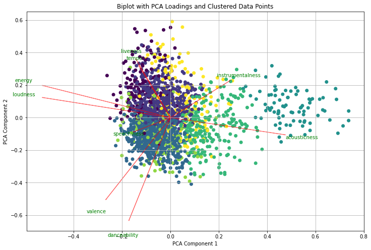

```python
# Function to create a biplot
def biplot(score,coeff,labels=None):
    xs = score[:,0]
    ys = score[:,1]
    n = coeff.shape[0]
    scalex = 1.0/(xs.max() - xs.min())
    scaley = 1.0/(ys.max() - ys.min())

    plt.figure(figsize=(12, 8))
    plt.scatter(xs * scalex,ys * scaley, c = df_unique['cluster_k7']) # Plotting the PCA scores

    for i in range(n):
        # Plot arrows
        plt.arrow(0, 0, coeff[i,0], coeff[i,1],color = 'r',alpha = 0.5)
        if labels is None:
            plt.text(coeff[i,0]* 1.15, coeff[i,1] * 1.15, "Var"+str(i+1), color = 'g', ha = 'center', va = 'center')
        else:
            plt.text(coeff[i,0]* 1.15, coeff[i,1] * 1.15, labels[i], color = 'g', ha = 'center', va = 'center')

    plt.xlabel("PCA Component 1")
    plt.ylabel("PCA Component 2")
    plt.grid()

# Plotting the biplot
biplot(X_pca_7, pca.components_.T, labels=features_for_clustering)
plt.title('Biplot with PCA Loadings and Clustered Data Points')
plt.show()
```

[output not shown]

##### High Energy and Loudness Cluster:

A cluster with high average values for energy and loudness likely represents tracks that are more intense, powerful, and suitable for energetic environments, such as dance music, electronic, or rock genres.

##### High Acousticness Cluster:

A cluster characterized by high acousticness and possibly lower values of energy could represent genres that are more acoustic and less electronic, such as folk, acoustic pop, or classical music.

##### High Danceability and Valence Cluster:

Tracks in a cluster with high danceability and valence scores are likely to be more upbeat, happier, and rhythmically engaging, suggesting genres like pop, disco, or certain types of upbeat electronic dance music.

##### Balanced Feature Cluster:

A cluster without extreme values in any direction could represent a wide variety of genres that don't fit neatly into the above categories, possibly including mainstream pop, rock, or hip-hop, where songs might have a balanced mix of acoustic and electronic elements, moderate energy and danceability, and a wide range of valences.

# Variance Across Clusters for Best Features

```python
# Calculate the mean values of the original features for each cluster
cluster_means = df_unique.groupby('cluster_k7')[features_for_clustering].mean()

# Calculate the variance of these mean values across clusters to identify the most distinguishing features
feature_variances = cluster_means.var().sort_values(ascending=False)

feature_variances
```

```
tempo               73.643854
loudness            22.677871
acousticness         0.106129
instrumentalness     0.103728
energy               0.060206
valence              0.027644
liveness             0.022470
danceability         0.011983
speechiness          0.009046
dtype: float64
```

##### Acousticness and Instrumentalness:

Both have notable variance, indicating these features play a significant role in distinguishing between clusters. This suggests clusters may differentiate between more acoustic vs. more electronic/instrumental tracks.

##### Energy:

Has moderate variance, further suggesting that the energy level of tracks helps differentiate between the clusters, possibly distinguishing more energetic tracks from more mellow ones.

##### Valence, Liveness, Danceability, and Speechiness:

Have lower variances but still contribute to the differentiation between clusters. These features might represent subtler distinctions, such as mood (valence), the presence of live recording aspects (liveness), rhythm and beat (danceability), and the amount of spoken words (speechiness).